# Asparagopsis parameteristation

# Fragmentation with exposure

- It has been suggested that “this species prefer semi-exposed areas as biomass production decreased with wave exposure” (Sainz-Villegas 2024 pg 66) but this was not tested in that study.
- May be worth including a dynamic “breakage” term, perhaps modifying $D_m$ such that it has a minimum value and increases with $U_0$ (or $U_0^2$?).

In Tasmania, *A. armata* are harvested after only 6 weeks because the shedding rate means they don’t get any additional biomass. There are two ways to implement this:

1. Manually, i.e. the model is only ever run for 6 weeks at a time with *Asparagopsis* (Camille White, pers comm).
- Disadvantage: no mechanistic recreation of shedding, that 6-week time frame will be fixed
- Advantage: fast and easy
2. Mechanistically, i.e. implementing a value of $D_m$ that increases over time.
- Disadvantage: additional uncertainty that comes with needing to create/parameterise a new function
- Advantages: mechanistic recreation of realistic conditions and culture practices, and a possible synergies with an exposure-based $D_m$ parameters

A loss term might end up looking like:
$$D_m = f(growdays) + f(h_m/h_{max}) + f(V)$$

Where $D_m$ is the % of biomass lost d$^{-1}$.

**Important**

Is fragmentation maybe a function of age (maturity) or length of thalli, in addition to exposure?

## Velocity

Hall (2023) investigated tetrasporophyte and gametophyte fragmentation at different levels of turbulence and water velocities. Focus of the study was on how fragmentation can be used in nurseries to enhance stock production. The laminar water velocities tested were:

- Low ( 0.25 m s$^{-1}$)
- Low-mid ( 0.37 m s$^{-1}$)
- Mid ( 0.52 m s$^{-1}$)
- Mid-high ( 0.81 m s$^{-1}$)
- High ( 1.14 m s$^{-1}$)
- Max-high ( 1.42 m s$^{-1}$)

These results are summarised in Figures 3.17, 3.18 and 3.19.

**Get Hall (2023) velocity data for gametophytes**

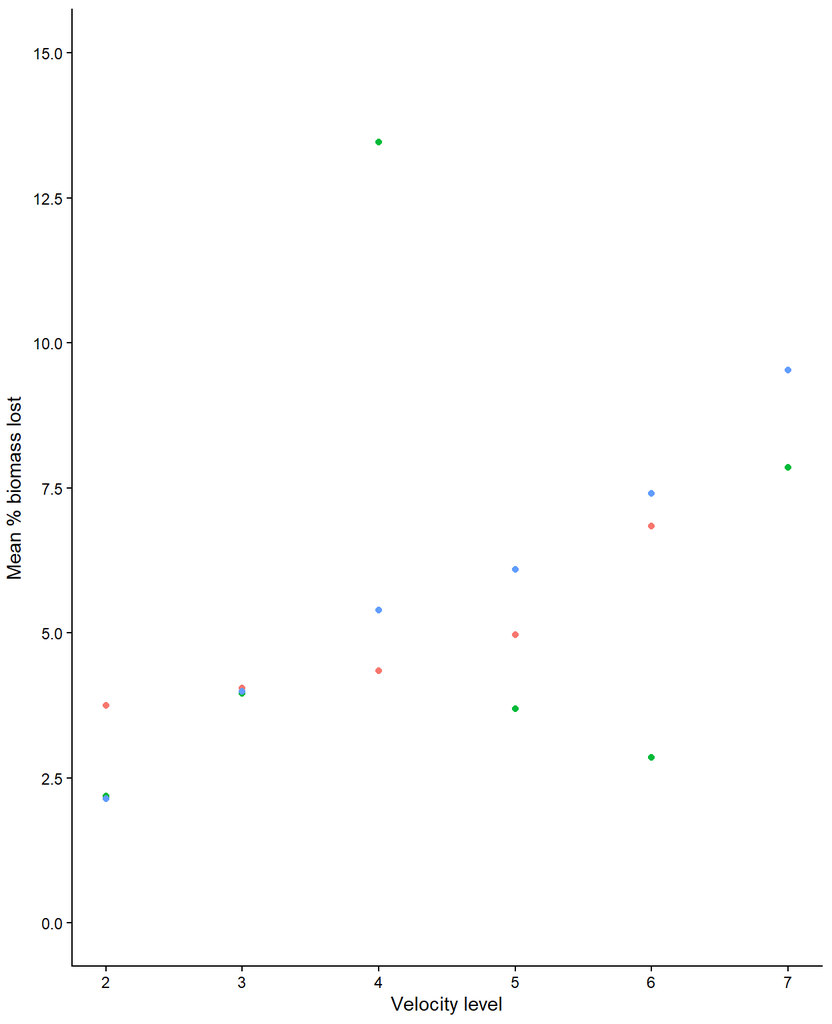

Combined data from Figures 3.17 (red), 3.18 (green) and 3.19 (blue) from Hall (2023) as they appear to be three different experiments with the same treatments.

```r
hall_data <- here() %>% file.path("data_raw", "sources", "hall_2023", "hall_2023.csv") %>% read.csv()
hall_names <- c("hall_2.9", "hall_3.17", "hall_3.18", "hall_3.19", "hall_3.28", "hall_3.29")
labels_4 <- c('static', 'low', 'mid', 'high')
labels_5 <- c('low', 'low_mid', 'mid', 'mid_high', 'high')
labels_6 <- c(labels_5, 'max_high')

hall_data <- split.default(hall_data, rep(hall_names, each = 4)[1:ncol(hall_data)]) %>%
  lapply(function(df){
    # Get information
    form <- ifelse(any(str_detect(colnames(df), "tetra")), "tetrasporophyte", "gametophyte") %>% unique()
    treat <- ifelse(any(str_detect(colnames(df), "VE")), "velocity", "turbulence") %>% unique()
    # Pare down to just data
    df <- df %>%
      mutate_all(as.numeric) %>%
      filter(!if_all(everything(), is.na))
    # Get the correct treatment labelling
    labels <- if (nrow(df) == 4) {labels_4} else if (nrow(df) == 5) {labels_5} else {labels_6}
    # Put dataframe together
    df <- df[,2:ncol(df)]
    colnames(df) <- c("mean", "label", "mean_se")
    df$label <- as.factor(labels)
    df$treat <- as.factor(treat)
    df$form <- as.factor(form)
    df
  }) %>%
  purrr::imap(., ~ mutate(.x, fig = .y)) %>%
  bind_rows() %>%
  mutate(se = mean_se - mean,
         fig = as.factor(fig),
         label = factor(label, levels = c("static", labels_6)))
hall_data <- here() %>% file.path("data_raw", "sources", "hall_2023", "hall_2023.csv") %>% read.csv()
hall_names <- c("hall_2.9", "hall_3.17", "hall_3.18", "hall_3.19", "hall_3.28", "hall_3.29")
labels_4 <- c('static', 'low', 'mid', 'high')
labels_5 <- c('low', 'low_mid', 'mid', 'mid_high', 'high')
labels_6 <- c(labels_5, 'max_high')

hall_data <- split.default(hall_data, rep(hall_names, each = 4)[1:ncol(hall_data)]) %>%
  lapply(function(df){
    # Get information
    form <- ifelse(any(str_detect(colnames(df), "tetra")), "tetrasporophyte", "gametophyte") %>% unique()
    treat <- ifelse(any(str_detect(colnames(df), "VE")), "velocity", "turbulence") %>% unique()
    # Pare down to just data
    df <- df %>%
      mutate_all(as.numeric) %>%
      filter(!if_all(everything(), is.na))
    # Get the correct treatment labelling
    labels <- if (nrow(df) == 4) {labels_4} else if (nrow(df) == 5) {labels_5} else {labels_6}
    # Put dataframe together
    df <- df[,2:ncol(df)]
    colnames(df) <- c("mean", "label", "mean_se")
    df$label <- as.factor(labels)
    df$treat <- as.factor(treat)
    df$form <- as.factor(form)
    df
  }) %>%
  purrr::imap(., ~ mutate(.x, fig = .y)) %>%
  bind_rows() %>%
  mutate(se = mean_se - mean,
         fig = as.factor(fig),
         label = factor(label, levels = c("static", labels_6)))

hall_gam_vel <- filter(hall_data, form == "gametophyte" & treat == "velocity")

p1 <- ggplot(hall_gam_vel, aes(x = as.numeric(label), y = mean*100, colour = fig)) +
  geom_point() +
  prettyplot +
  scale_y_continuous(limits = c(0,15), breaks = seq(0,15,2.5)) +
  labs(x = "Velocity level", y = "Mean % biomass lost")

p1
```

I’m not sure what’s going on with Velocity Experiment 2 (in green, above) but the other two experiments show a clear trend of biomass lost with increasing velocity.

**Create linear relationship for velocity**

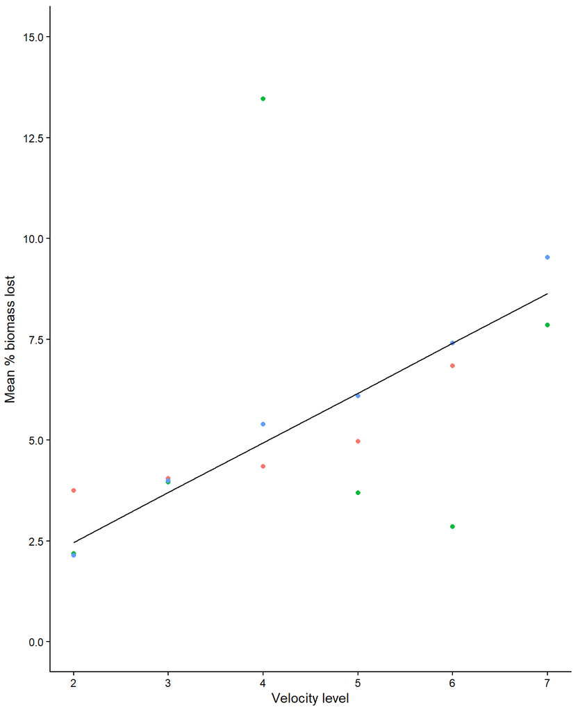

Add linear relationship to above plot

```r
hall_gam_vel2 <- hall_gam_vel %>%
  filter(fig != "hall_3.18")

line_a <- nls(
  formula = as.formula(mean ~ a * as.numeric(label)),
  start = c(a = 0.1),
  data = hall_gam_vel2
  )

D_ve <- unname(coef(line_a)) %>% set_units("d-1")

p2 <- p1 +
  geom_line(data = hall_gam_vel2, aes(x = as.numeric(label), y = 100*drop_units(D_ve)*as.numeric(label)), colour = "black")

p2
```

## Turbulence

Hall (2023) also investigated fragmentation due to turbulence on the gametophyte, which is summarised in Figures 3.28 and 3.29.

**Get Hall (2023) turbulence data for gametophytes**

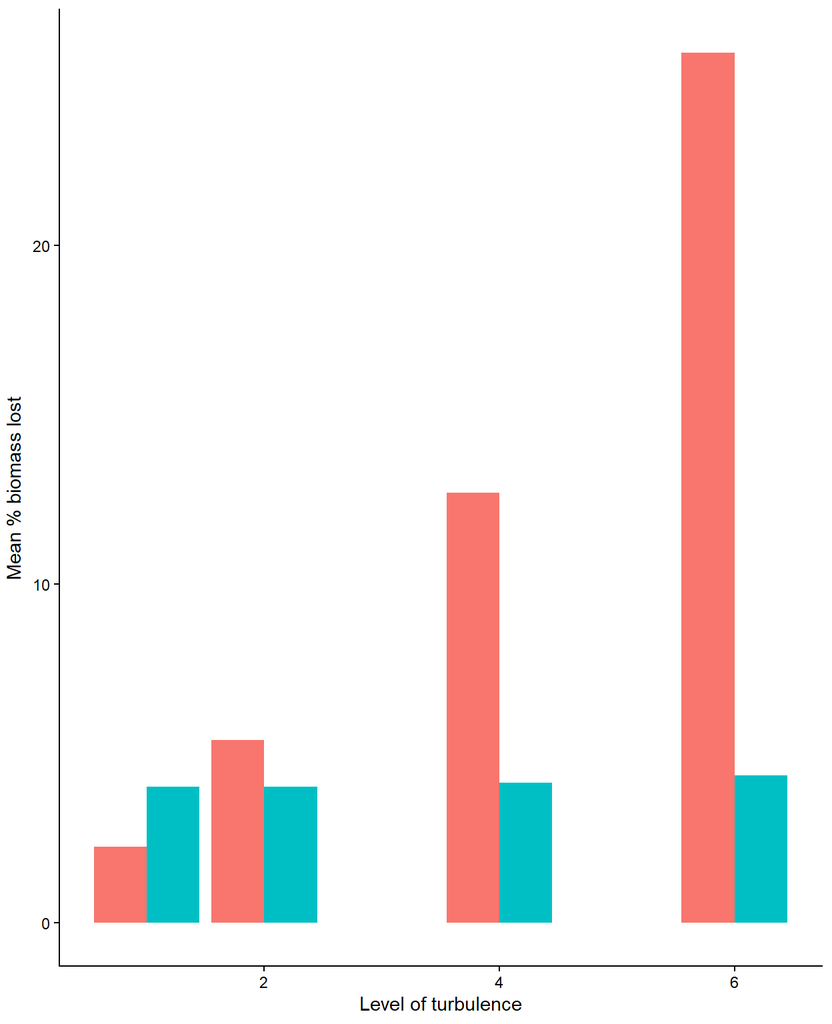

Combined data from Figures 3.28 (red) and 3.29 (blue) from Hall (2023) as they appear to be two different experiments with the same treatments.

```r
hall_gam_turb <- hall_data %>%
  filter(form == "gametophyte" & treat == "turbulence")

p1 <- ggplot(hall_gam_turb, aes(x = as.numeric(label), y = mean*100, fill = fig)) +
  geom_col(position = "dodge") +
  prettyplot +
  labs(x = "Level of turbulence", y = "Mean % biomass lost")

p1
```

Looks very different between the two experiments, but I’m going to go with the one that shows a clear trend.

**Get turbulence data ready for vector**

```r
D_st <- D_m <- hall_gam_turb$mean[hall_gam_turb$label == "static"] %>% mean() %>% set_units("d-1")
D_lo <- hall_gam_turb$mean[hall_gam_turb$label == "low"] %>% max() %>% set_units("d-1")
D_mi <- hall_gam_turb$mean[hall_gam_turb$label == "mid"] %>% max() %>% set_units("d-1")
D_hi <- hall_gam_turb$mean[hall_gam_turb$label == "high"] %>% max() %>% set_units("d-1")
```

# Finishing up

## All parameters and sources

Table 3 shows exactly what’s going into the species vectors. Note that only one of $V_{am}$ & $K_{am}$ or $M_{am}$ & $C_{am}$ will be used as the macroalgae will not have both linear and Michaelis-Menton uptake of the same nutrient.

[output not shown]

Table 3: Final values for species parameters before saving. These are displayed both for transparency and to check that the units have converted correctly.

| Parameter | Units | *A. armata* value | *A. taxiformis* value | Sources |
| --- | --- | --- | --- | --- |
| $V_{am}$ | umolN/(gDW*h) | $14.85$ |  | Schuenhoff et al. (2006) |
| $K_{am}$ | umolN/L | $10.01$ |  | Schuenhoff et al. (2006) |
| $M_{am}$ | L/(h*gDW) | $0.1400$ |  | Torres et al. (2021) |
| $C_{am}$ | umolN/(h*gDW) | $8.790$ |  | Torres et al. (2021) |
| $M_{ni}$ | L/(h*gDW) | $-1.382 \times 10^{-3}$ |  | Torres et al. (2021) |
| $C_{ni}$ | umolN/(gDW*h) | $0.4430$ |  | Torres et al. (2021) |
| $M_{ot}$ | L/(h*gDW) | $6.000 \times 10^{-3}$ |  | Torres et al. (2021) |
| $C_{ot}$ | umolN/(h*gDW) | $0.8800$ |  | Torres et al. (2021) |
| $K_{c}$ | - | $\mathrm{NA}$ |  | Hadley et al. (2015) |
| $Q_{min}$ | mgN/gDW | $19.43$ |  | Mihaila et al. (2022); Zemke-White and Clements (1999); Angell et al. (2016) |
| $Q_{max}$ | mgN/gDW | $65.00$ |  | Schuenhoff et al. (2006) |
| $DWWW$ | gWW | $7.115$ |  | Nunes et al. (2024); Roque et al. (2019) |
| $\mu$ | 1/d | $0.1667$ |  |  |
| $D_{m}$ | 1/d | $3.133 \times 10^{-2}$ |  |  |
| $D_{v}$ | 1/d | $1.233 \times 10^{-2}$ |  |  |
| $D_{lo}$ | 1/d | $5.390 \times 10^{-2}$ |  |  |
| $D_{mi}$ | 1/d | $0.1270$ |  |  |
| $D_{hi}$ | 1/d | $0.2568$ |  |  |
| $I_o$ | mol/(m^2*s) | $150.0$ |  |  |
| $a_{cs}$ | m/mgN | $2.801 \times 10^{-6}$ |  |  |
| $T_{opt}$ | °C | $19.09$ | $24.62$ |  |
| $T_{min}$ | °C | $8.895$ | $16.03$ |  |
| $T_{max}$ | °C | $22.43$ | $29.23$ |  |
| $S_{opt}$ | g/L | $35.25$ |  |  |
| $S_{min}$ | g/L | $21.15$ |  |  |
| $S_{max}$ | g/L | $41.65$ |  |  |
| $h_a$ | - | $1.794 \times 10^{3}$ |  |  |
| $h_b$ | - | $1.500$ |  |  |
| $h_c$ | - | $1.000 \times 10^{-2}$ |  |  |
| $h_{max}$ | m | $0.2600$ |  |  |

## Saving data

**Insert values and units into named vector**

```r
param_units <- c(
  "mg gDW-1 d-1",                                              # V_am
  "mg m-3",                                                    # K_am
  rep("m3 gDW-1 d-1", 2),                                      # M_am, C_am
  "mg gDW-1 d-1",                                              # V_ni
  "mg m-3",                                                    # K_ni
  rep("m3 gDW-1 d-1", 2),                                      # M_ni, C_ni
  "mg gDW-1 d-1",                                              # V_ot
  "mg m-3",                                                    # K_ot
  rep("m3 gDW-1 d-1", 2),                                      # M_ot, C_ot
  rep("mg gDW-1", 3),                                          # Q_min, Q_max, K_c
  "d-1",                                                       # mu
  # rep("g gDW-1", 2),                                           # N_min, N_max
  rep("d-1", 5),                                               # D_m
  "m mg-1",                                                    # a_cs
  "umol photons m-2 s-1",                                      # I_o
  rep("degrees C", 3),                                         # T_opt, T_min, T_max
  rep("g L-1", 3),                                             # S_opt, S_min, S_max
  rep("d-1", 3),                                               # h_a, h_b, h_c
  "m",                                                         # h_max
  "gWW gDW-1"                                                  # DWWW
  )

a_armata <- c(
  V_am = V_am %>% set_units("mgN gDW-1 d-1") %>% drop_units(),
  K_am = K_am %>% set_units("mgN m-3") %>% drop_units(),
  M_am = M_am %>% set_units("m3 gDW-1 d-1") %>% drop_units(),
  C_am = C_am %>% set_units("mgN gDW-1 d-1") %>% drop_units(),
  V_ni = V_ni,
  K_ni = K_ni,
  M_ni = M_ni,
  C_ni = C_ni %>% set_units("mgN gDW-1 d-1") %>% drop_units(),
  V_ot = V_ot,
  K_ot = K_ot,
  M_ot = M_ot %>% set_units("m3 gDW-1 d-1") %>% drop_units(),
  C_ot = C_ot %>% set_units("mgN gDW-1 d-1") %>% drop_units(),
  Q_min = drop_units(Q_min),
  Q_max = drop_units(Q_max),
  K_c = drop_units(Q_min) * 0.85,
  mu = drop_units(mu),
  # N_min = N_min,
  # N_max = N_max,
  D_m = drop_units(D_m),
  D_ve = drop_units(D_ve),
  D_lo = drop_units(D_lo),
  D_mi = drop_units(D_mi),
  D_hi = drop_units(D_hi),
  a_cs = drop_units(a_cs),                  # or a_cs from figueroa 2006?
  I_o = drop_units(I_o),
  T_opt = T_opt_arma,
  T_min = T_min_arma,
  T_max = T_max_arma,
  S_opt = S_opt,
  S_min = S_min,
  S_max = S_max,
  h_a = h_a,
  h_b = h_b,
  h_c = h_c,
  h_max = drop_units(h_max),
  DWWW = DWWW
  )

a_taxiformis <- a_armata
a_taxiformis['T_opt'] <- T_opt_taxi
a_taxiformis['T_max'] <- T_max_taxi
a_taxiformis['T_min'] <- T_min_taxi
a_armata <- c(
  V_am = V_am %>% set_units("mgN gDW-1 d-1") %>% drop_units(),
  K_am = K_am %>% set_units("mgN m-3") %>% drop_units(),
  M_am = M_am %>% set_units("m3 gDW-1 d-1") %>% drop_units(),
  C_am = C_am %>% set_units("mgN gDW-1 d-1") %>% drop_units(),
  V_ni = V_ni,
  K_ni = K_ni,
  M_ni = M_ni,
  C_ni = C_ni %>% set_units("mgN gDW-1 d-1") %>% drop_units(),
  V_ot = V_ot,
  K_ot = K_ot,
  M_ot = M_ot %>% set_units("m3 gDW-1 d-1") %>% drop_units(),
  C_ot = C_ot %>% set_units("mgN gDW-1 d-1") %>% drop_units(),
  Q_min = drop_units(Q_min),
  Q_max = drop_units(Q_max),
  K_c = drop_units(Q_min) * 0.85,
  mu = drop_units(mu),
  # N_min = N_min,
  # N_max = N_max,
  D_m = drop_units(D_m),
  D_ve = drop_units(D_ve),
  D_lo = drop_units(D_lo),
  D_mi = drop_units(D_mi),
  D_hi = drop_units(D_hi),
  a_cs = drop_units(a_cs),                  # or a_cs from figueroa 2006?
  I_o = drop_units(I_o),
  T_opt = T_opt_arma,
  T_min = T_min_arma,
  T_max = T_max_arma,
  S_opt = S_opt,
  S_min = S_min,
  S_max = S_max,
  h_a = h_a,
  h_b = h_b,
  h_c = h_c,
  h_max = drop_units(h_max),
  DWWW = DWWW
  )

a_taxiformis <- a_armata
a_taxiformis['T_opt'] <- T_opt_taxi
a_taxiformis['T_max'] <- T_max_taxi
a_taxiformis['T_min'] <- T_min_taxi
```

The model uses a named vector, which can be loaded straight from Rdata files, but I’m saving as a .csv file because that’s easier for human reading.

**Save named vector and .csv file**

```r
# Save data as a named vector - model uses this
qsave(a_armata, file = file.path(out_path, "asparagopsis_armata.qs"))
qsave(a_taxiformis, file = file.path(out_path, "asparagopsis_taxiformis.qs"))

# Save duplicates as CSV - easier for humans to read
write.csv(
  data.frame(
    parameter = names(a_armata),
    unit = as.character(param_units),
    value = (unname(a_armata))
  ),
  file.path(out_path, "asparagopsis_armata.csv")
)

write.csv(
  data.frame(
    parameter = names(a_taxiformis),
    unit = as.character(param_units),
    value = (unname(a_taxiformis))
  ),
  file.path(out_path, "asparagopsis_taxiformis.csv")
)

# Save duplicates as CSV - easier for humans to read
write.csv(
  data.frame(
    parameter = names(a_armata),
    unit = as.character(param_units),
    value = (unname(a_armata))
  ),
  file.path(out_path, "asparagopsis_armata.csv")
)

write.csv(
  data.frame(
    parameter = names(a_taxiformis),
    unit = as.character(param_units),
    value = (unname(a_taxiformis))
  ),
  file.path(out_path, "asparagopsis_taxiformis.csv")
)
```

# Potential future extensions

## Limitation by other nutrients

It has been suggested that the model should include the possibility of phosphorus limitation, as well as nitrogen limitation (switching between the limiting nutrient based on availability/internal conditions). This was considered because the places where macroalgae is being grown for nitrogen bioremediation purposes (river outflows, next to fish farms) are likely to be very high in nitrogen but not necessarily phosphates.

However, it was decided not to include phosphorus limitation. While the mechanics of including it would be fairly simple, research into the required parameters (shape and rate of uptake, internal requirements) are almost non-existent for *Asparagopsis*. Grisenthwaite (2023) may possibly have some of this data for tetrasporophytes(?) but I have yet to find anything similar for gametophytes. If the ‘standard’, not species-specific Atkinson ratio of N:P were assumed (Atkinson and Smith 1983), then the algae would require 1/30<sup>th</sup> as much phosphorus as nitrogen to maintain the modelled growth. Given that macroalgae require so much more nitrogen than phosphorus, it seems unlikely that they are ever going to be phosphorus limited in coastal or oceanic waters. Phosphates are also not often measured in marine waters, so obtaining ambient data would be extremely difficult.

Still, if the Atkinson ratio (30:1 N:P) were assumed and phosphate uptake kinetics were ignored, then the minimum phosphate concentrations required to maintain the modelled growth can be estimated and reported as an additional consideration.

- Dissolved inorganic carbon may be a major (perhaps determining?) limiting factor for growth and photosynthesis in *Asparagopsis* (Zanolla et al. 2022; Mata et al. 2010)
- Sainz-Villegas (2024) and Sainz-Villegas et al. (2024) investigated the survival of vegetative propagules (juvenile gametophytes) - potential to estimate propagation/spread based on wave exposure
- Mata et al. (2017) looked at temperature effects on the production of bromoforms

## References

Angell, Alex R., Leonardo Mata, Rocky De Nys, and Nicholas A. Paul. 2016. ‘The Protein Content of Seaweeds: A Universal Nitrogen-to-Protein Conversion Factor of Five’. *Journal of Applied Phycology* 28 (1): 511–24. http://doi.org/10.1007/s10811-015-0650-1.

Atkinson, M. J., and S. V. Smith. 1983. ‘C:N:P Ratios of Benthic Marine Plants’. *Limnology and Oceanography* 28 (3): 568–74. https://doi.org/10.4319/lo.1983.28.3.0568.

Brooke, Charles G., Breanna M. Roque, Claire Shaw, et al. 2020. ‘Methane Reduction Potential of Two Pacific Coast Macroalgae During in Vitro Ruminant Fermentation’. *Frontiers in Marine Science* 7. https://doi.org/10.3389/fmars.2020.00561.

Chualáin, Fionnuala Ní, Christine A. Maggs, Gary W. Saunders, and Michael D. Guiry. 2004. ‘The Invasive Genus *Asparagopsis* (Bonnemaisoniaceae, Rhodophyta): Molecular Systematics, Morphology, and Ecophysiology of *Falkenbergia* Isolates’. *Journal of Phycology* 40 (6): 1112–26. https://doi.org/10.1111/j.1529-8817.2004.03135.x.

Cole, Andrew J., Leonardo Mata, Nicholas A. Paul, and Rocky De Nys. 2014. ‘Using CO$_{\textrm{2}}$ to Enhance Carbon Capture and Biomass Applications of Freshwater Macroalgae’. *GCB Bioenergy* 6 (6): 637–45. https://doi.org/10.1111/gcbb.12097.

Dijoux, Laury, Frédérique Viard, and Claude Payri. 2014. ‘The More We Search, the More We Find: Discovery of a New Lineage and a New Species Complex in the Genus *Asparagopsis*’. *PLOS ONE* 9 (7): e103826. https://doi.org/10.1371/journal.pone.0103826.

Dishon, Gal, Hannah M. Resetarits, Brandon Tsai, Ashley L. Jones, Vinayak Agarwal, and Jennifer E. Smith. 2023. ‘The Effect of Light Intensity, Spectrum, and Photoperiod on the Physiological Performance of *Asparagopsis Taxiformis* Tetrasporophytes’. *Algal Research* 76: 103304. https://doi.org/10.1016/j.algal.2023.103304.

Figueroa, Félix L., Rui Santos, Rafael Conde-Álvarez, et al. 2006. ‘The Use of Chlorophyll Fluorescence for Monitoring Photosynthetic Condition of Two Tank-Cultivated Red Macroalgae Using Fishpond Effluents’. *Botanica Marina* 49 (4): 275–82. https://doi.org/10.1515/BOT.2006.035.

Grisenthwaite, Robert David Karr. 2023. ‘Establishing Land Tank Cultivation of Asparagopsis Taxiformis in Scotland’. Master of {Research}, University of the Highlands; Islands.

Hadley, Scott A., Karen A. Wild-Allen, Craig R. Johnson, and Catriona K. MacLeod. 2015. ‘Modeling Macroalgae Growth and Nutrient Dynamics for Integrated Multi-Trophic Aquaculture’. *Journal of Applied Phycology* 27 (2): 901–16. http://doi.org/10.1007/s10811-014-0370-y.

Hall, Ailise Maree. 2023. ‘Investigating the Effects of Water Motion on Fragmentation of the Red Seaweed *Asparagopsis Armata*’. Master of {Science}, University of Auckland.

Kraan, Stefan, and Kelly A. Barrington. 2005. ‘Commercial Farming of *Asparagopsis Armata* (Bonnemaisoniceae, Rhodophyta) in Ireland, Maintenance of an Introduced Species?’ *Journal of Applied Phycology* 17 (2): 103–10. https://doi.org/10.1007/s10811-005-2799-5.

Mata, Leonardo. 2008. ‘Integrated Aquaculture of Bonnemaisoniaceae: Physiological and Nutritional Controls of Biomass Production and of Halogenated Metabolite Content’. Doctor of {Philosophy} in {Marine} {Sciences}, University of Algarve.

Mata, Leonardo, Rebecca J. Lawton, Marie Magnusson, Nikos Andreakis, Rocky De Nys, and Nicholas A. Paul. 2017. ‘Within-Species and Temperature-Related Variation in the Growth and Natural Products of the Red Alga *Asparagopsis Taxiformis*’. *Journal of Applied Phycology* 29 (3): 1437–47. http://doi.org/10.1007/s10811-016-1017-y.

Mata, Leonardo, Andreas Schuenhoff, and Rui Santos. 2010. ‘A Direct Comparison of the Performance of the Seaweed Biofilters, *Asparagopsis Armata* and *Ulva Rigida*’. *Journal of Applied Phycology* 22 (5): 639–44. https://doi.org/10.1007/s10811-010-9504-z.

Mata, Leonardo, João Silva, Andreas Schuenhoff, and Rui Santos. 2006. ‘The Effects of Light and Temperature on the Photosynthesis of the *Asparagopsis Armata* Tetrasporophyte (*Falkenbergia Rufolanosa*), Cultivated in Tanks’. *Aquaculture*, Seaweed-Based Integrated Mariculture, vol. 252 (1): 12–19. https://doi.org/10.1016/j.aquaculture.2005.11.045.

McDermid, Karla J., and Brooke Stuercke. 2003. ‘Nutritional Composition of Edible Hawaiian Seaweeds’. *Journal of Applied Phycology* 15 (6): 513–24. https://doi.org/10.1023/B:JAPH.0000004345.31686.7f.

Mihaila, Alisa A., Christopher R. K. Glasson, Rebecca Lawton, Stefan Muetzel, German Molano, and Marie Magnusson. 2022. ‘New Temperate Seaweed Targets for Mitigation of Ruminant Methane Emissions: An in Vitro Assessment’. *Applied Phycology* 3 (1): 274–84. https://doi.org/10.1080/26388081.2022.2059700.

Mihaila, Alisa A., Rebecca J. Lawton, Christopher R. K. Glasson, and Marie Magnusson. 2024. ‘Moderate Temperature and Water Flow Increase Growth During the Nursery Phase of *Asparagopsis Armata*’. *Algal Research* 78: 103380. https://doi.org/10.1016/j.algal.2023.103380.

Monro, Keyne. 2007. ‘Evolutionary Consequences of Growth-Form Plasticity in a Red Seaweed’. Doctor of {Philosophy}, University of New South Wales. http://doi.org/10.26190/unsworks/17535.

Nunes, Helder P. B., Cristiana S. A. M. Maduro Dias, Nuno V. Álvaro, and Alfredo E. S. Borba. 2024. ‘Evaluation of Two Species of Macroalgae from Azores Sea as Potential Reducers of Ruminal Methane Production: In Vitro Ruminal Assay’. *Animals* 14 (6): 967. https://doi.org/10.3390/ani14060967.

Pacheco, Diana, Glacio Souza Araújo, João Cotas, Rui Gaspar, João M. Neto, and Leonel Pereira. 2020. ‘Invasive Seaweeds in the Iberian Peninsula: A Contribution for Food Supply’. *Marine Drugs* 18 (11): 560. https://doi.org/10.3390/md18110560.

Padilla-Gamiño, Jacqueline L., and Robert C. Carpenter. 2007. ‘Seasonal Acclimatization of *Asparagopsis Taxiformis* (Rhodophyta) from Different Biogeographic Regions’. *Limnology and Oceanography* 52 (2): 833–42. https://doi.org/10.4319/lo.2007.52.2.0833.

Roque, Breanna Michell, Charles Garrett Brooke, Joshua Ladau, et al. 2019. ‘Effect of the Macroalgae *Asparagopsis Taxiformis* on Methane Production and Rumen Microbiome Assemblage’. *Animal Microbiome* 1 (1): 3. https://doi.org/10.1186/s42523-019-0004-4.

Sainz-Villegas, Samuel. 2024. ‘Modelling the Effects of Climate Change on the Distribution of Subtidal Macroalgae: The Role of Vegetative Propagation’. Doctor of {Philosophy}, Universidad de Cantabria.

Sainz-Villegas, Samuel, Begoña Sánchez-Astráin, Araceli Puente, and José A. Juanes. 2024. ‘Exploring the Effects of Temperature and Light Availability on the Vegetative Propagation Processes of the Non-Native Species *Asparagopsis Armata*’. *Frontiers in Marine Science* 10: 1343353. https://doi.org/10.3389/fmars.2023.1343353.

Schuenhoff, Andreas, Leonardo Mata, and Rui Santos. 2006. ‘The Tetrasporophyte of *Asparagopsis Armata* as a Novel Seaweed Biofilter’. *Aquaculture*, Seaweed-Based Integrated Mariculture, vol. 252 (1): 3–11. https://doi.org/10.1016/j.aquaculture.2005.11.044.

Torres, Raquel C., Ana M. Campos, Jacob Goldman, Isabel Barrote, Leonardo Mata, and João Silva. 2024. ‘Effects of Light Quality and Intensity on Growth and Bromoform Content of the Red Seaweed *Asparagopsis Taxiformis*’. *Journal of Applied Phycology* 36 (2): 627–37. https://doi.org/10.1007/s10811-023-03052-6.

Torres, Raquel C., Leonardo Mata, Rui Santos, and Ana Alexandre. 2021. ‘Nitrogen Uptake Kinetics of an Enteric Methane Inhibitor, the Red Seaweed *Asparagopsis Armata*’. *Journal of Applied Phycology* 33 (6): 4001–9. https://doi.org/10.1007/s10811-021-02604-y.

Wiltshire, Kathryn H., Jason E. Tanner, C. Fred D. Gurgel, and Marty R. Deveney. 2015. *Feasibility Study for Integrated Multitrophic Aquaculture in Southern Australia*. {SARDI} {Publication} F2015/000786-1.

Wright, Jeffrey T., Elysha J. Kennedy, Rocky de Nys, and Masayuki Tatsumi. 2022. ‘Asexual Propagation of *Asparagopsis Armata* Gametophytes: Fragmentation, Regrowth and Attachment Mechanisms for Sea-Based Cultivation’. *Journal of Applied Phycology* 34 (4): 2135–44. https://doi.org/10.1007/s10811-022-02763-6.

Zanolla, Marianela, María Altamirano, Raquel Carmona, et al. 2018. ‘Assessing Global Range Expansion in a Cryptic Species Complex: Insights from the Red Seaweed Genus *Asparagopsis* (Florideophyceae)’. *Journal of Phycology* 54 (1): 12–24. https://doi.org/10.1111/jpy.12598.

Zanolla, Marianela, María Altamirano, Julio De La Rosa, Francisco X. Niell, and Raquel Carmona. 2018. ‘Size Structure and Dynamics of an Invasive Population of Lineage 2 of *Asparagopsis Taxiformis* (Florideophyceae) in the Alboran Sea’. *Phycological Research* 66 (1): 45–51. https://doi.org/10.1111/pre.12189.

Zanolla, Marianela, M. Altamirano, R. Carmona, J. De La Rosa, A. Sherwood, and N. Andreakis. 2015. ‘Photosynthetic Plasticity of the Genus *Asparagopsis* (Bonnemaisoniales, Rhodophyta) in Response to Temperature: Implications for Invasiveness’. *Biological Invasions* 17 (5): 1341–53. https://doi.org/10.1007/s10530-014-0797-8.

Zanolla, Marianela, M. Altamirano, F. X. Niell, and R. Carmona. 2019. ‘There Is More Than Meets the Eye: Primary Production of the Invasive Seaweed *Asparagopsis Taxiformis* (Bonnemaisoniaceae, Rhodophyta) Is Provided by Six Cohorts with Distinctive Characteristics’. *Aquatic Botany* 153: 24–28. https://doi.org/10.1016/j.aquabot.2018.11.007.

Zanolla, Marianela, Raquel Carmona, Julio De La Rosa, and María Altamirano. 2018. ‘Structure and Temporal Dynamics of a Seaweed Assemblage Dominated by the Invasive Lineage 2 of *Asparagopsis Taxiformis* (Bonnemaisoniaceae, Rhodophyta) in the Alboran Sea’. *Mediterranean Marine Science* 19 (1): 147. https://doi.org/10.12681/mms.1892.

Zanolla, Marianela, Raquel Carmona, Leonardo Mata, et al. 2022. ‘Concise Review of the Genus *Asparagopsis* Montagne, 1840’. *Journal of Applied Phycology* 34 (1): 1–17. https://doi.org/10.1007/s10811-021-02665-z.

Zemke-White, W. Lindsey, and K. D. Clements. 1999. ‘Chlorophyte and Rhodophyte Starches as Factors in Diet Choice by Marine Herbivorous Fish’. *Journal of Experimental Marine Biology and Ecology* 240 (1): 137–49. https://doi.org/10.1016/S0022-0981(99)00056-8.